# Reproducable Research Project 2

Yaswanth Pulavarthi

8/3/2020

# SYNOPSIS

Data is transformed by type of events and listed out top 10 losses in each category and represented the damage by event into a plot and visualized which event caused more damage

## 1 Data processing

loaded the data using read.csv function, because it can automatically extracts file and load into csv. just took the required columns needed for analysis and set cache= TRUE.

## load data

```r
read.csv("C:\\Users\\Yaswanth Pulavarthi\\Downloads\\repdata_data_StormData.csv.bz2")->data
names(data)
```

```
##  [1] "STATE__"    "BGN_DATE"   "BGN_TIME"   "TIME_ZONE"  "COUNTY"
##  [6] "COUNTYNAME" "STATE"      "EVTYPE"     "BGN_RANGE"  "BGN_AZI"
## [11] "BGN_LOCATI" "END_DATE"   "END_TIME"   "COUNTY_END" "COUNTYENDN"
## [16] "END_RANGE"  "END_AZI"    "END_LOCATI" "LENGTH"     "WIDTH"
## [21] "F"          "MAG"        "FATALITIES" "INJURIES"   "PROPDMG"
## [26] "PROPDMGEXP" "CROPDMG"    "CROPDMGEXP" "WFO"        "STATEOFFIC"
## [31] "ZONENAMES"  "LATITUDE"   "LONGITUDE"  "LATITUDE_E" "LONGITUDE_"
## [36] "REMARKS"    "REFNUM"
```

```r
req.col<-c("EVTYPE","FATALITIES","INJURIES","PROPDMG","PROPDMGEXP","CROPDMG","CROPDMGEXP" )
data<-data[,req.col]
head(data)
```

```
##    EVTYPE FATALITIES INJURIES PROPDMG PROPDMGEXP CROPDMG CROPDMGEXP
## 1 TORNADO          0       15    25.0          K       0
## 2 TORNADO          0        0     2.5          K       0
## 3 TORNADO          0        2    25.0          K       0
## 4 TORNADO          0        2     2.5          K       0
## 5 TORNADO          0        2     2.5          K       0
## 6 TORNADO          0        6     2.5          K       0
```

## damagecosts

### property damage costs

listed the types of property damage expenses using unique function

```r
unique(data$PROPDMGEXP)
```

```
##  [1] "K" "M" ""  "B" "m" "+" "0" "5" "6" "?" "4" "2" "3" "h" "7" "H" "-" "1" "8"
```

changed the character variables of PROPDMGEXP into numbers .i.e: K =1000,M=1,000,000 and 0 for invalid data(?,+,-). And, created new colomn in data table, which gives the information about property loss

```r
# Assigning values for the property data
data$PROPEXP[data$PROPDMGEXP == "K" | data$PROPDMGEXP == "3"] <- 1000
data$PROPEXP[data$PROPDMGEXP == "M" | data$PROPDMGEXP == "m" | data$PROPDMGEXP == "6"] <- 1e+06
data$PROPEXP[data$PROPDMGEXP == ""] <- 1
data$PROPEXP[data$PROPDMGEXP == "B"] <- 1e+09
data$PROPEXP[data$PROPDMGEXP == "0"] <- 1
data$PROPEXP[data$PROPDMGEXP == "5"] <- 1e+05
data$PROPEXP[data$PROPDMGEXP == "4"] <- 10000
data$PROPEXP[data$PROPDMGEXP == "2" | data$PROPDMGEXP == "h" | data$PROPDMGEXP == "H"] <- 100
data$PROPEXP[data$PROPDMGEXP == "7"] <- 1e+07
data$PROPEXP[data$PROPDMGEXP == "1"] <- 10
data$PROPEXP[data$PROPDMGEXP == "8"] <- 1e+08
# Assigning '0' to invalid data
data$PROPEXP[data$PROPDMGEXP == "+" | data$PROPDMGEXP == "-" |data$PROPDMGEXP == "?"] <- 0
# Calculating the property damage value
data$PROPDMGCOST <- data$PROPDMG * data$PROPEXP
```

Similarly, like above changed the exponent data into numbers and created a new column with crop damage loss

```r
unique(data$CROPDMGEXP)
```

```
## [1] ""  "M" "K" "m" "B" "?" "0" "k" "2"
```

```r
# Assigning values for the crop exponent data
data$CROPEXP[data$CROPDMGEXP == "M" | data$CROPDMGEXP == "m"] <- 1e+06
data$CROPEXP[data$CROPDMGEXP == "K" | data$CROPDMGEXP == "k"] <- 1000
data$CROPEXP[data$CROPDMGEXP == "B"] <- 1e+09
data$CROPEXP[data$CROPDMGEXP == "0" | data$CROPDMGEXP == ""] <- 1
data$CROPEXP[data$CROPDMGEXP == "2"] <- 100

# Assigning '0' to invalid exponent data
data$CROPEXP[data$CROPDMGEXP == "?"] <- 0
# calculating the crop damage value
data$CROPDMGCOST <- data$CROPDMG * data$CROPEXP
```

Sorted the data by event types for Fatalities, Injuries,Property Damage Costs,Crop damage Costs. And by using sorted data, listed out top 10 events caused high loss.

```r
 fatal <- aggregate(FATALITIES ~ EVTYPE, data, FUN = sum)
fatal10 <- fatal[order(-fatal$FATALITIES), ][1:10, ]
 injury <- aggregate(INJURIES ~ EVTYPE, data, FUN = sum)
injury10 <- injury[order(-injury$INJURIES), ][1:10, ]
 propdmg <- aggregate(PROPDMGCOST ~ EVTYPE, data, FUN = sum)
propdmg10 <- propdmg[order(-propdmg$PROPDMGCOST), ][1:10, ]
 cropdmg <- aggregate(CROPDMGCOST ~ EVTYPE, data, FUN = sum)
cropdmg10 <- cropdmg[order(-cropdmg$CROPDMGCOST), ][1:10, ]
```

ploted the top 10 events for high fatalities and high injuries

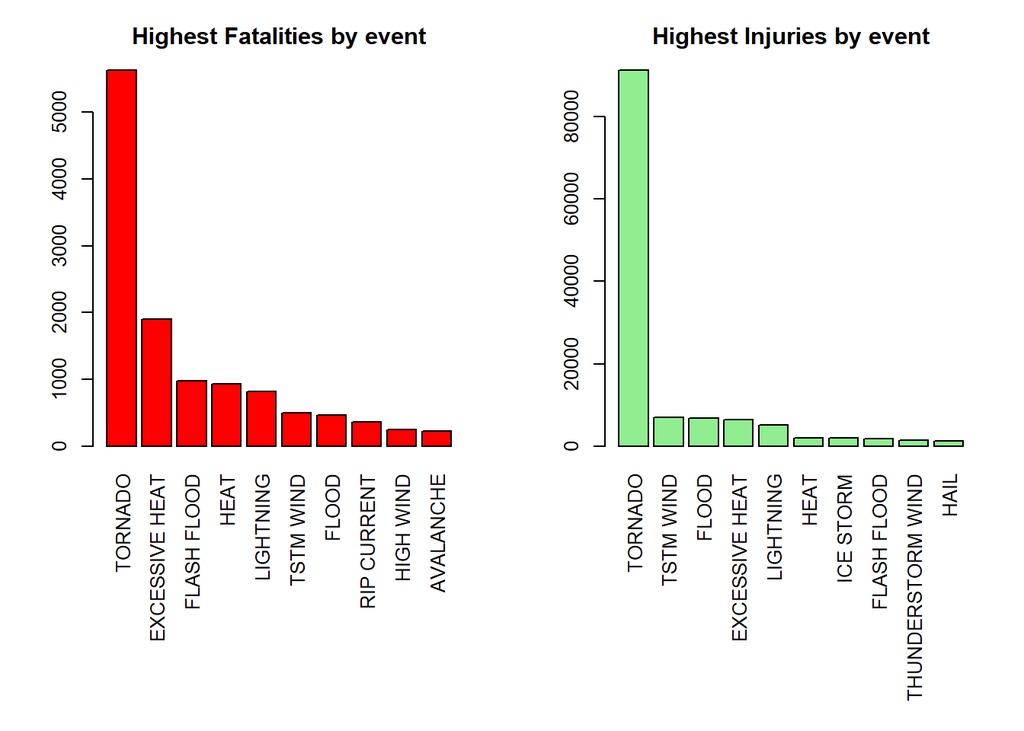

```r
 par(mfrow = c(1, 2), mar = c(12, 4, 3, 2), mgp = c(3, 1, 0), cex = 0.8)
 barplot(fatal10$FATALITIES, las = 3, names.arg = fatal10$EVTYPE, main = "Highest Fatalities by event", col = "red")
 barplot(injury10$INJURIES, las = 3, names.arg = injury10$EVTYPE, main = "Highest Injuries by event", col = "light green")
```

ploted top 10 events for high crop and property loss

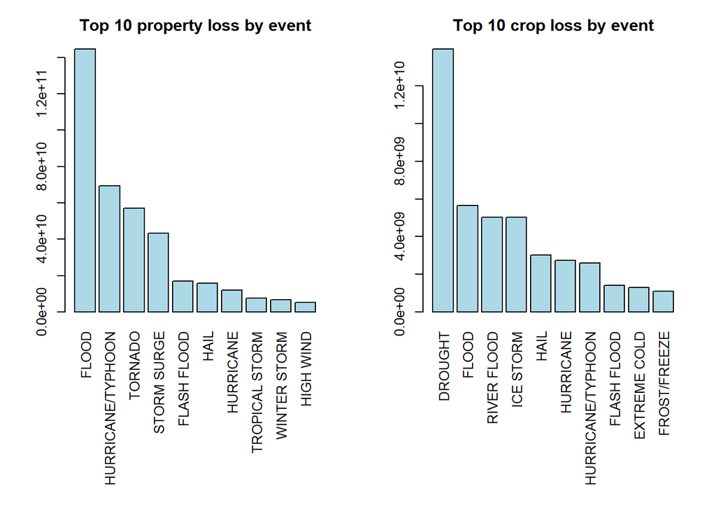

```r
par(mfrow = c(1, 2), mar = c(12, 4, 3, 2), mgp = c(3, 1, 0), cex = 0.8)
barplot(propdmg10$PROPDMGCOST, las = 3, names.arg = propdmg10$EVTYPE, main = "Top 10 property loss by event", col = "light blue")
barplot(cropdmg10$CROPDMGCOST, las = 3, names.arg = cropdmg10$EVTYPE, main = "Top 10 crop loss by event", col = "light blue")
```

# Result

As per plot-1, there are highest fatalities and injuries due to Tornado. Highest Property damage due to Floods and highest crop damage due to Droughts